# Lab 6: Regularization — Breaking OLS, Then Rescuing It

ECON 8310: Business Forecasting — University of Nebraska at Omaha

# What we are doing

Lecture 6 claimed that ordinary least squares breaks when you have many predictors relative to observations — coefficient variance grows with $k$, correlated predictors produce wild offsetting estimates, and past $k > n$ there is no unique solution at all.

Today you will break it on purpose, watch exactly how it fails, and then fix it with one line.

Same series as Labs 4 and 5: daily units for CA_1 FOODS. But we now engineer the feature set an analyst would actually build — 28 consecutive lags, weekly and annual lags, rolling statistics, Fourier terms, day-of-week dummies — which is how you end up with more predictors than you meant to have.

**Suggested time:** ~40 minutes · **You will need:** `pandas`, `numpy`, `matplotlib`, `scikit-learn`, and `data/processed/m5_daily.csv`.

# Setup

```python
import pandas as pd
import numpy as np
import matplotlib.pyplot as plt
from sklearn.linear_model import LinearRegression, Lasso, Ridge
from sklearn.preprocessing import StandardScaler
from sklearn.pipeline import make_pipeline
from sklearn.model_selection import TimeSeriesSplit, cross_val_score
import warnings
warnings.filterwarnings('ignore')

from pathlib import Path

def data_path(name):
    for base in (Path.cwd(), *Path.cwd().parents):
        p = base / "data" / "processed" / name
        if p.exists():
            return p
    raise FileNotFoundError(
        f"Could not find data/processed/{name}. "
        "Run `python scripts/prep_m5.py` from the repository root first."
    )

RANDOM_STATE = 42

daily = pd.read_csv(data_path("m5_daily.csv"), parse_dates=["date"]).sort_values("date")
u = daily.set_index("date")["units"]

for L in list(range(1, 29)) + [35, 42, 49, 56, 364, 365, 366]:
    daily[f"lag{L}"] = u.shift(L).values
for W in (7, 14, 28, 91, 364):
    daily[f"roll{W}_mean"] = u.shift(1).rolling(W).mean().values
    daily[f"roll{W}_std"]  = u.shift(1).rolling(W).std().values

daily["dow"] = daily["date"].dt.dayofweek
daily["doy"] = daily["date"].dt.dayofyear
for k in (1, 2, 3):
    daily[f"sin{k}"] = np.sin(2*np.pi*k*daily.doy/365)
    daily[f"cos{k}"] = np.cos(2*np.pi*k*daily.doy/365)
daily = pd.concat([daily, pd.get_dummies(daily.dow, prefix="dow")], axis=1)

FEATURES = ([c for c in daily.columns if c.startswith(("lag", "roll", "sin", "cos", "dow_"))]
            + ["snap", "is_event", "doy", "avg_price"])

df = daily.dropna(subset=[c for c in FEATURES if c.startswith(("lag", "roll"))]).copy()
N_TEST = 365
train, test = df.iloc[:-N_TEST], df.iloc[-N_TEST:]
X_train, y_train = train[FEATURES].values.astype(float), train["units"].values
X_test,  y_test  = test[FEATURES].values.astype(float),  test["units"].values

rmse = lambda a, b: float(np.sqrt(np.mean((np.asarray(a) - np.asarray(b)) ** 2)))

print(f"k = {len(FEATURES)} features, n_train = {len(X_train)}, n/k = {len(X_train)/len(FEATURES):.1f}")
```

```
k = 62 features, n_train = 1210, n/k = 19.5
```

Note how easily 62 predictors appeared. Nobody set out to build a 62-parameter model; it is what routine feature engineering produces.

# Step 1 — Break it

With 1,210 training rows and 62 features, OLS is fine. Now shrink the training window and watch.

```python
rows = []
for n in (1210, 400, 200, 120, 80):
    sub = train.iloc[-n:]
    sc = StandardScaler().fit(sub[FEATURES].values.astype(float))
    Xs = sc.transform(sub[FEATURES].values.astype(float))
    Xt = sc.transform(X_test)
    y  = sub["units"].values

    ols = LinearRegression().fit(Xs, y)
    rid = Ridge(alpha=100).fit(Xs, y)

    rows.append({"n": n, "n/k": round(n/len(FEATURES), 1),
                 "OLS_max_coef": f"{np.abs(ols.coef_).max():,.0f}",
                 "OLS_test_RMSE": f"{rmse(y_test, ols.predict(Xt)):,.0f}",
                 "Ridge_test_RMSE": f"{rmse(y_test, rid.predict(Xt)):,.0f}"})

print(pd.DataFrame(rows).to_string(index=False))
```

```
   n  n/k OLS_max_coef OLS_test_RMSE Ridge_test_RMSE
1210 19.5          153           280             278
 400  6.5          636         2,071             323
 200  3.2        1,364         5,874             363
 120  1.9    1,049,739     3,578,141             621
  80  1.3      355,629     2,072,167             770
```

**Read that table across, then down.** As the training window shrinks, the largest OLS coefficient grows from about 150 to the hundreds of thousands, and the test RMSE from 280 into the millions. Nothing about the *problem* changed — same features, same target, same test set. Only the ratio of observations to parameters.

Ridge, with a one-line change, degrades gracefully across the entire range.

That is Lecture 6’s opening argument, and you just measured it.

# Step 2 — Two penalties, two behaviors

Back to the full training set. Fit Ridge and LASSO at a comparable penalty and count what survives.

```python
sc = StandardScaler().fit(X_train)
Xs, Xts = sc.transform(X_train), sc.transform(X_test)

for name, model in [("OLS",   LinearRegression()),
                    ("Ridge", Ridge(alpha=100)),
                    ("LASSO", Lasso(alpha=20, max_iter=50000))]:
    m = model.fit(Xs, y_train)
    nz = int(np.sum(m.coef_ != 0))
    print(f"  {name:<6} test RMSE {rmse(y_test, m.predict(Xts)):5,.0f}   non-zero coefficients {nz:3d}/{len(FEATURES)}")
```

```
  OLS    test RMSE   280   non-zero coefficients  62/62
  Ridge  test RMSE   278   non-zero coefficients  62/62
  LASSO  test RMSE   286   non-zero coefficients  21/62
```

Ridge keeps every coefficient and shrinks them. LASSO sets most of them to exactly zero. Neither is “better” — they encode different beliefs about how many predictors genuinely matter.

# Step 3 — The path, and the order features die in

Lecture 6 argued that the **order** predictors leave is a more stable finding than any single coefficient table. Produce that ordering.

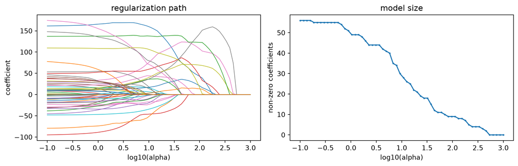

```python
alphas = np.logspace(-1, 3, 60)
paths = []
for a in alphas:
    paths.append(Lasso(alpha=a, max_iter=50000).fit(Xs, y_train).coef_)
paths = np.array(paths)

fig, axes = plt.subplots(1, 2, figsize=(11, 3.6))
axes[0].plot(np.log10(alphas), paths, lw=0.8)
axes[0].set_xlabel("log10(alpha)"); axes[0].set_ylabel("coefficient"); axes[0].set_title("regularization path")
axes[1].plot(np.log10(alphas), (paths != 0).sum(1), marker=".", ms=3)
axes[1].set_xlabel("log10(alpha)"); axes[1].set_ylabel("non-zero coefficients"); axes[1].set_title("model size")
plt.tight_layout()
```

```python
survivors, order = set(FEATURES), []
for a, coefs in zip(alphas, paths):
    nz = set(np.array(FEATURES)[coefs != 0])
    for gone in survivors - nz:
        order.append(gone)
    survivors = nz

print("the last 8 features standing, in reverse order of elimination:")
for f in reversed(order[-8:]):
    print(f"   {f}")
```

```
the last 8 features standing, in reverse order of elimination:
   lag28
   lag7
   lag35
   lag364
   lag14
   lag1
   lag21
   lag56
```

**Look at what survived**

Read that list of survivors and find the pattern in the lag numbers before reading on.

Almost all of them are **multiples of 7**. Nobody told the model this series has a weekly cycle, and there is no explicit “week” feature among the lags. Under increasing penalty the LASSO independently kept the lags that align with day-of-week and discarded the ones that do not.

That is what makes the dropout ordering worth reporting: it recovered the structure of the series, not just a ranking of columns.

# Step 4 — Choosing alpha, and the one-standard-error rule

```python
tscv = TimeSeriesSplit(n_splits=5)
grid = np.logspace(-1, 2.5, 30)

means, ses = [], []
for a in grid:
    s = cross_val_score(make_pipeline(StandardScaler(), Lasso(alpha=a, max_iter=50000)),
                        X_train, y_train, cv=tscv, scoring="neg_root_mean_squared_error")
    means.append(-s.mean()); ses.append(s.std()/np.sqrt(len(s)))
means, ses = np.array(means), np.array(ses)

i_min = int(means.argmin())
threshold = means[i_min] + ses[i_min]
i_1se = int(np.where(means <= threshold)[0].max())

for label, i in [("CV minimum", i_min), ("one-SE rule", i_1se)]:
    m = make_pipeline(StandardScaler(), Lasso(alpha=grid[i], max_iter=50000)).fit(X_train, y_train)
    print(f"  {label:<12} alpha {grid[i]:7.2f}   CV {means[i]:5,.0f}   "
          f"test {rmse(y_test, m.predict(X_test)):5,.0f}   non-zero {int(np.sum(m[-1].coef_ != 0)):3d}")
```

```
  CV minimum   alpha   19.64   CV   323   test   286   non-zero  21
  one-SE rule  alpha   59.68   CV   346   test   309   non-zero  11
```

**Your turn:** plot the CV curve with its one-standard-error band, and mark both chosen alphas.

```python
# ---- your turn: uncomment and fill in the blank ----
# fig, ax = plt.subplots(figsize=(7, 3.4))
# ax.plot(np.log10(grid), means)
# ax.fill_between(np.log10(grid), means - ses, means + ses, alpha=0.2)
# ax.axvline(np.log10(grid[i_min]), ls="--", label="CV minimum")
# ax.axvline(np.log10(___), ls=":", label="one-SE")        # <- which index?
# ax.set_xlabel("log10(alpha)"); ax.set_ylabel("CV RMSE"); ax.legend()
# plt.tight_layout()
```

The one-SE rule roughly halves the number of surviving features. **Decide whether that trade is worth it here** — and say what you would need to know about how the model will be used before you could answer properly.

# Step 5 — Why your CV number looks worse than the truth

The CV RMSE above is noticeably higher than the test RMSE. That is not a mistake, and the reason is sitting in Step 1.

```python
for i, (tr_idx, va_idx) in enumerate(tscv.split(X_train), 1):
    m = make_pipeline(StandardScaler(), Lasso(alpha=20, max_iter=50000)).fit(X_train[tr_idx], y_train[tr_idx])
    print(f"  fold {i}: train n={len(tr_idx):4d} (n/k={len(tr_idx)/len(FEATURES):4.1f})   "
          f"val n={len(va_idx):3d}   RMSE {rmse(y_train[va_idx], m.predict(X_train[va_idx])):5,.0f}")
```

```
  fold 1: train n= 205 (n/k= 3.3)   val n=201   RMSE   433
  fold 2: train n= 406 (n/k= 6.5)   val n=201   RMSE   294
  fold 3: train n= 607 (n/k= 9.8)   val n=201   RMSE   325
  fold 4: train n= 808 (n/k=13.0)   val n=201   RMSE   257
  fold 5: train n=1009 (n/k=16.3)   val n=201   RMSE   308
```

Fold 1 trains on about 200 rows — the same data-starved regime that wrecked OLS in Step 1. The final model trains on all 1,210. So walk-forward CV on an expanding window is **structurally pessimistic**: it averages in early folds that are trained on far less data than the model you actually ship.

That is a reason to read the CV number as a conservative estimate, not a reason to abandon it — and emphatically not a reason to switch to random folds, which fix the pessimism by letting the model see the future.

# Before you leave

Add today’s best linear model to the scoreboard you have been building since Lab 4.

```python
best = make_pipeline(StandardScaler(), Lasso(alpha=grid[i_min], max_iter=50000)).fit(X_train, y_train)
board = {
    "Benchmark (same day last year)": rmse(y_test, test.units_lag365.values),
    "Single tree (Lab 4)": 324,
    "Random Forest (Lab 5)": 248,
    "XGBoost (Lab 5)": 244,
    "LASSO, 62 features (today)": rmse(y_test, best.predict(X_test)),
}
print(pd.Series(board).round(0).astype(int).sort_values(ascending=False).to_string())
```

```
Benchmark (same day last year)    625
Single tree (Lab 4)               324
LASSO, 62 features (today)        286
Random Forest (Lab 5)             248
XGBoost (Lab 5)                   244
```

> **Discuss:** The regularized linear model does **not** win here — the tree ensembles beat it on this series. Give one property of daily store sales that favors trees over an additive linear model, however many lags you give it.

> Then the counterpoint, which matters for Homework 4: on the *weekly, 30-series* panel the ranking may not look the same. What is different about that problem that could change the answer?

> **And the one to argue about:** you have now fitted five model families to this one series. If you had to hand exactly one of them to a store manager who will not be retrained, and who will not retune anything for a year, which do you choose — and is it the one with the lowest RMSE?

*Solutions posted to Canvas after class.*